# Analyzing Social Media Usage

Omar Nava

2024-05-22

# Introduction

Social Media has become an integral part of modern life in terms of communication and keeping up with others. Understanding the impact that different social media platforms can have on users can help provide insight onto creating boundaries for ourselves when it comes to utilizing them. The purpose of this study is to analyze social media media usage with emotional well-being along with verifying if there are any relationships between daily usage among age categorized by gender.

# Methodology

The analysis for this study was conducted using R, in particular utilizing the libraries dplyr for data manipulation and ggplot2 for visualizing the data. The study includes: 1. Identifying the most common emotions associated with each platform. 2. Ranking the platforms based on total time spent along with average daily time spent. 3. Analyzing the most common platforms for each gender. 4. Examining if there’s a correlation between daily usage time and age, categorizing by different genders.

# Data Set

The data set is sourced from Kaggle, licensed under Massachusetts Institute of Technology. It contains 10 variables (columns) along with 1001 entries (rows) before filtering.The variables include User ID, Age, Gender, Platform, Daily Usage Time (in minutes), Posts Per Day, Likes Received Per Day, Comments Received Per Day, Messages Sent Per Day, and Dominant Emotion. The variables included both numerical and categorical.

Which platform was the most common for each emotion?

```r
platform_emotion <- social |>
  group_by(Dominant_Emotion) |>
  summarize(Most_Common_Platform = Platform[which.max((table(Platform)))])

print(platform_emotion)
```

```
## # A tibble: 6 × 2
##   Dominant_Emotion Most_Common_Platform
##   <chr>            <chr>
## 1 Anger            Twitter
## 2 Anxiety          Instagram
## 3 Boredom          LinkedIn
## 4 Happiness        Instagram
## 5 Neutral          Facebook
## 6 Sadness          Instagram
```

# Results

The results for most dominant associated with each platform seem to align with the general consensus. Twitter is typically a very political charged platform, LinkedIn is used for job-hunting, and Facebook is typically used as a functional platform for messaging, purchasing items, etc. The most interesting results come from Instagram, which were associated with a variety of emotions including Anxiety, Happiness, and Sadness. Ranking the platforms with the most time spent on it

```r
time_spent_platform <- social |>
  group_by(Platform) |>
  summarise(Total_Time_Spent = sum(`Daily_Usage_Time..minutes.`, na.rm = TRUE)) |>
  arrange(desc(Total_Time_Spent))

print(time_spent_platform)
```

```
## # A tibble: 7 × 2
##   Platform  Total_Time_Spent
##   <chr>                <dbl>
## 1 Instagram            36220
## 2 Twitter              15800
## 3 Facebook             12900
## 4 LinkedIn              6580
## 5 Snapchat              6190
## 6 Whatsapp              6030
## 7 Telegram              5270
```

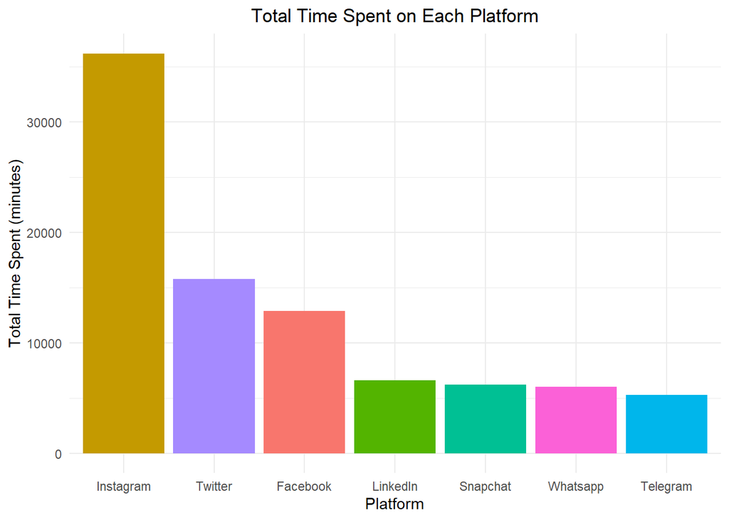

```r
ggplot(time_spent_platform, aes(x=reorder(Platform,-Total_Time_Spent), y=Total_Time_Spent, fill=Platform)) +
  geom_bar(stat="identity") +
  labs(title="Total Time Spent on Each Platform",
       x="Platform",
       y="Total Time Spent (minutes)") +
  theme_minimal() +
  theme(plot.title = element_text(hjust = 0.5), legend.position = "none")
```

# Results

Instagram had by far the most time spent on it with 36,220 minutes. More than double the second most Platform (Twitter). In terms of understanding the results, it makes sense that Telegram, Whatsapp, and Snapchat have the least amount of time spent since they are primarily used for communication. Instagram, Twitter, and Facebook to some extent (The top 3) are also used for entertainment purposes.

# Ranking the platforms with the most time spent on it

```r
# Filter out rows with NA values in Daily Usage Time
social <- social |> filter(!is.na(Daily_Usage_Time..minutes.))

# Calculate the average daily usage time for each platform
average_time_spent_platform <- social |>
  group_by(Platform) |>
  summarise(Average_Daily_Usage_Time = mean(Daily_Usage_Time..minutes., na.rm = TRUE)) |>
  arrange(desc(Average_Daily_Usage_Time))

# Print the result
print(average_time_spent_platform)
```

```
## # A tibble: 7 × 2
##   Platform  Average_Daily_Usage_Time
##   <chr>                        <dbl>
## 1 Instagram                    153.
## 2 Snapchat                      91.0
## 3 Whatsapp                      88.7
## 4 Twitter                       84.0
## 5 Telegram                      77.5
## 6 Facebook                      72.5
## 7 LinkedIn                      55.8
```

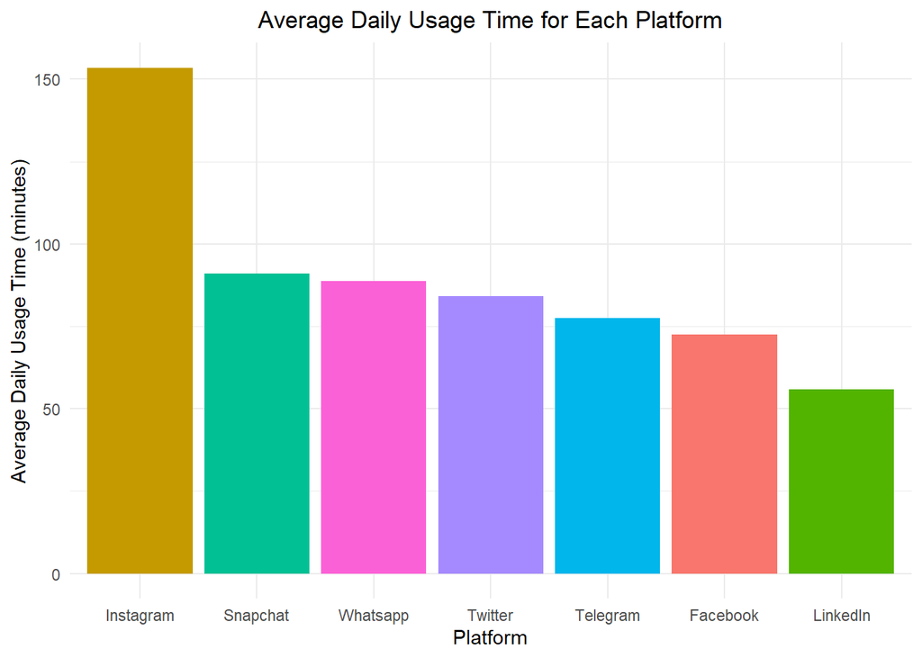

```r
# Create a bar plot for the average daily usage time for each platform
ggplot(average_time_spent_platform, aes(x=reorder(Platform, -Average_Daily_Usage_Time),
                                        y=Average_Daily_Usage_Time,
                                        fill=Platform)) +
  geom_bar(stat="identity") +
  labs(title="Average Daily Usage Time for Each Platform",
       x="Platform",
       y="Average Daily Usage Time (minutes)") +
  theme_minimal() +
  theme(plot.title = element_text(hjust = 0.5), legend.position = "none")
```

# Results Similar to most time spent on each platform, the average daily usage time for each platform yielded Instagram as the highest. What was interesting was that the rest of the results did not match up with the most time spent on each platform. The rest of the platforms were in a similar ballpark of ~75-90 minutes of average daily usage with the notable exception of LinkedIn which was closer to an average of 50 minutes per day.

# Most common platform for each gender

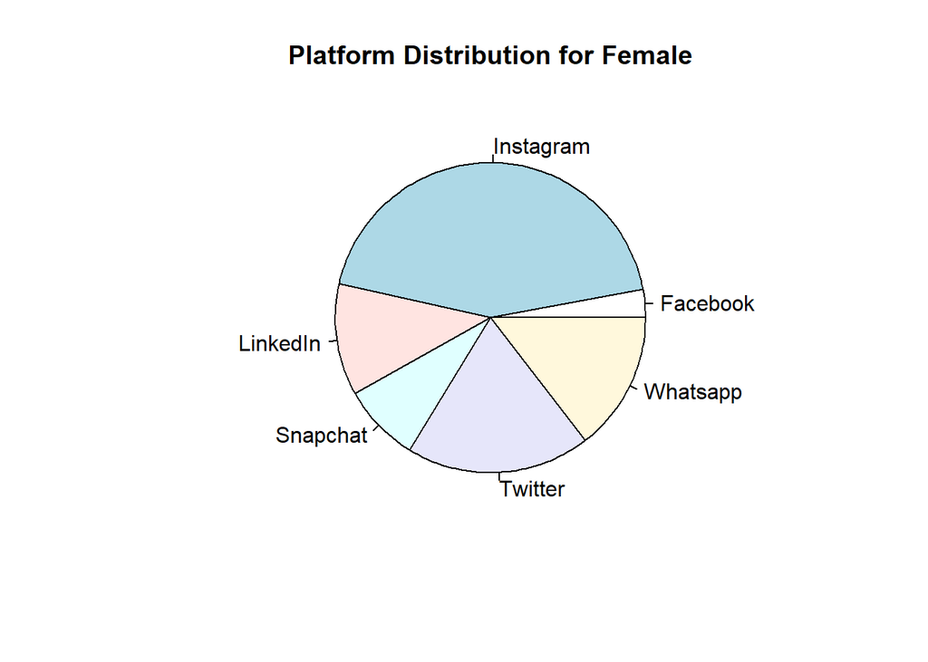

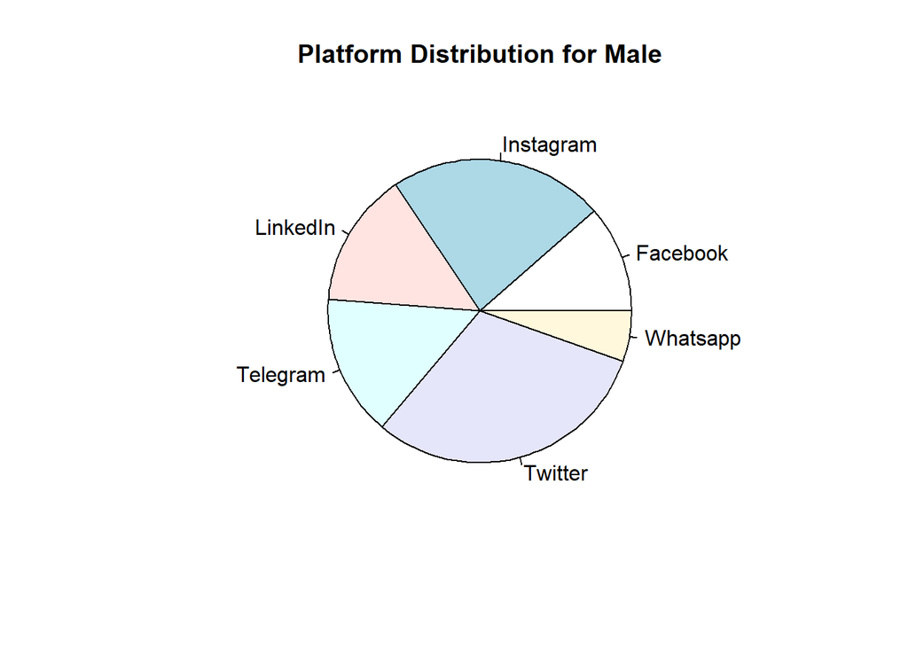

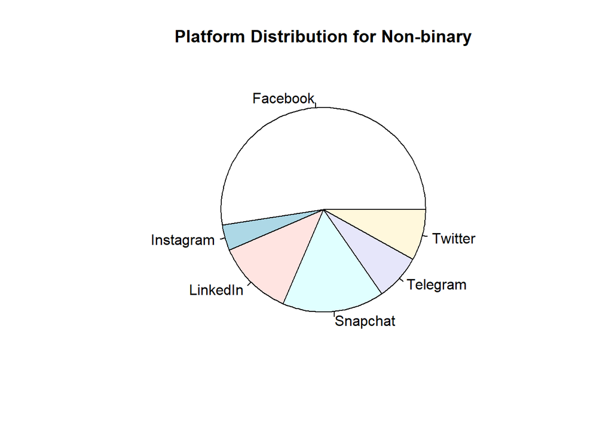

```r
# Pie Chart of Each Platform per Gender:
filtered_social <- social |> filter(!(Gender %in% c('Marie', '27')))

unique_genders <- unique(filtered_social$Gender)

for (gender in unique_genders)
{
  gender_data <- filtered_social |> filter(Gender == gender)
  platform_counts <- table(gender_data$Platform)

  pie(platform_counts,
      main=paste("Platform Distribution for", gender))
}
```

# Results Categorizing the distribution of platform use by gender, the most dominant platform for Females was Instagram, for Males it was Twitter, and for Non-binary it was Facebook. Visually it looks like the Male distribution was the most spread out, and the least was Non-binary.